# ISA616-Project2-Group3

- Show All Code
- Hide All Code
- View Source

Author

Nate Bosworth and Anthony Gusich

Published

October 12, 2023

## Audience and Purpose

The purpose of this analysis is to provide information on the relationship between number of internships and full time job placement characteristics (salary, preferred location/field) to FSB Career Services. This will help them give more accurate guidance to students to ensure they get the best full time opportunity for them.

## Business Value Proposition

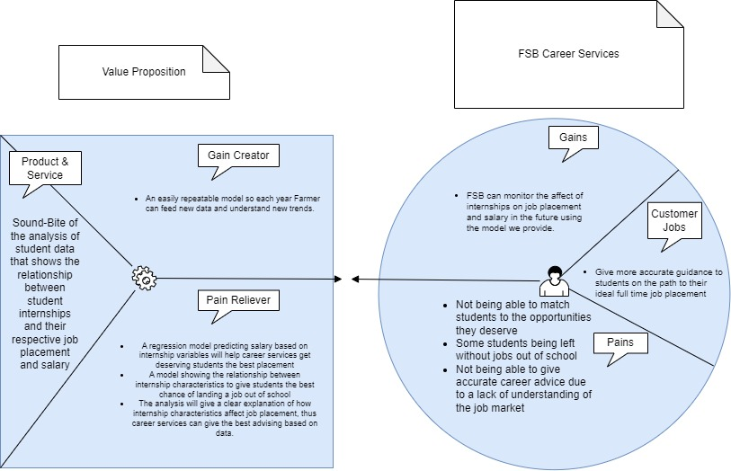

## Data Description

Annually, the FSB conducts a senior survey of graduates to learn of their employment status. In addition, information is verified using LinkedIn and employer survey information. The data contains data on graduates for 2019, 2020, and 2021. The data are merged from two sources: the senior survey, and data from the Miami University database.

```r
pacman::p_load(tidyverse)
```

## Change name of data

```r
fsb <- readRDS("FSB_BI_Survey_2019_2021.rds")
```

# Data Cleaning

## Subset dataframe into columns we need

**Justification: We created a subset of the data to only include the 3 variables we want in our model. We kept the survey_internships so we have the number of internships the student had, we kept the survey_salary so we can find the effect that number of internships has on salary and lastly we kept survey_state in order to keep state constant in our model so we can only focus on the effect of number of internships on salary.**

```r
df <- fsb[, c('survey_internships', 'survey_salary', 'survey_state')]
```

## Remove rows with NA salary

**Justification: We removed the null values from survey_salary because we didn’t want to include rows that don’t have a value for salary.**

```r
df <- df[!is.na(df$survey_salary), ]
```

## Define rows to remove and remove them from the data

**Justification: We removed values in survey_state that were practically null values. Many responses had either NA, TBD, TBA, or only included USA/United States. These responses do not provide much value to our model so we decided it was best to remove them.**

```r
to_remove <- c("Remote", "na", "NA", "TBA / USA", "TBD", "United States", "US", "USA")

df <- df %>%
  filter(!survey_state %in% to_remove)
```

## Set N/A internship values to 0 and remove RPT row

**Justification: We set all null values in the survey_internships column to 0. There was also an N/A and “RPT” response, so we set N/A to 0 and removed the row with RPT . We assumed that if the response is null that the student did not have an internship so the value should be 0.**

```r
df$survey_internships[is.na(df$survey_internships)] <- 0

df$survey_internships[df$survey_internships == "N/A"] <- 0

df <- df %>%
  filter(!survey_internships %in% "RPT")
```

## Standardize all state/country names (really annoying)

**Justification: The responses for survey_state varied since there was not a drop down selection for State. To clean this data we set all values that relate to a state, such as “Ohio”, “Oh”, “oh”, or “Ohio/USA” to one common value of “OH”. We did the same process for each of the states.**

```r
df$survey_state <- gsub("California", "CA", df$survey_state)
df$survey_state <- gsub("LA", "CA", df$survey_state)
df$survey_state <- gsub("Colorado/ United States", "CO", df$survey_state)
df$survey_state <- gsub("Colorado", "CO", df$survey_state)
df$survey_state <- gsub("Connecticut", "CT", df$survey_state)
df$survey_state <- gsub("D.C.", "DC", df$survey_state)
df$survey_state <- gsub("District of Columbia", "DC", df$survey_state)
df$survey_state <- gsub("Florida", "FL", df$survey_state)
df$survey_state <- gsub("Georgia, USA", "GA", df$survey_state)
df$survey_state <- gsub("Georgia", "GA", df$survey_state)
df$survey_state <- gsub("Illinois / USA", "IL", df$survey_state)
df$survey_state <- gsub("Illinois, USA", "IL", df$survey_state)
df$survey_state <- gsub("Illinois/ US", "IL", df$survey_state)
df$survey_state <- gsub("Illinois/USA", "IL", df$survey_state)
df$survey_state <- gsub("IL, USA", "IL", df$survey_state)
df$survey_state <- gsub("IL, US", "IL", df$survey_state)
df$survey_state <- gsub("IL/ USA", "IL", df$survey_state)
df$survey_state <- gsub("IL/USA", "IL", df$survey_state)
df$survey_state <- gsub("IL, United States", "IL", df$survey_state)
df$survey_state <- gsub("iL", "IL", df$survey_state)
df$survey_state <- gsub("Il", "IL", df$survey_state)
df$survey_state <- gsub("illinois", "IL", df$survey_state)
df$survey_state <- gsub("Illinois", "IL", df$survey_state)
df$survey_state <- gsub("ILlinois", "IL", df$survey_state)
df$survey_state <- gsub("IN / USA", "IN", df$survey_state)
df$survey_state <- gsub("Indiana / USA", "IN", df$survey_state)
df$survey_state <- gsub("Indiana", "IN", df$survey_state)
df$survey_state <- gsub("Ireland", "IR", df$survey_state)
df$survey_state <- gsub("Kansas", "KS", df$survey_state)
df$survey_state <- gsub("Kentucky", "KY", df$survey_state)
df$survey_state <- gsub("Massachusetts, USA", "MA", df$survey_state)
df$survey_state <- gsub("MA / USA", "MA", df$survey_state)
df$survey_state <- gsub("Maine", "ME", df$survey_state)
df$survey_state <- gsub("Michigan, Detroit", "MI", df$survey_state)
df$survey_state <- gsub("Michigan", "MI", df$survey_state)
df$survey_state <- gsub("MI / U.S.", "MI", df$survey_state)
df$survey_state <- gsub("Minnesota", "MN", df$survey_state)
df$survey_state <- gsub("Montana", "MT", df$survey_state)
df$survey_state <- gsub("Nebraska", "NE", df$survey_state)
df$survey_state <- gsub("New York, USA", "NY", df$survey_state)
df$survey_state <- gsub("New York", "NY", df$survey_state)
df$survey_state <- gsub("New york", "NY", df$survey_state)
df$survey_state <- gsub("North Carolina", "NC", df$survey_state)
df$survey_state <- gsub("Ohio/USA", "OH", df$survey_state)
df$survey_state <- gsub("Ohio/United States", "OH", df$survey_state)
df$survey_state <- gsub("Ohio/ United States", "OH", df$survey_state)
df$survey_state <- gsub("Ohio, USA", "OH", df$survey_state)
df$survey_state <- gsub("Ohio / USA", "OH", df$survey_state)
df$survey_state <- gsub("Ohio / United States", "OH", df$survey_state)
df$survey_state <- gsub("Ohio / The United States", "OH", df$survey_state)
df$survey_state <- gsub("OHIO", "OH", df$survey_state)
df$survey_state <- gsub("Ohio", "OH", df$survey_state)
df$survey_state <- gsub("ohio", "OH", df$survey_state)
df$survey_state <- gsub("OH/USA", "OH", df$survey_state)
df$survey_state <- gsub("OH/Us", "OH", df$survey_state)
df$survey_state <- gsub("OH, USA", "OH", df$survey_state)
df$survey_state <- gsub("oh", "OH", df$survey_state)
df$survey_state <- gsub("Oh", "OH", df$survey_state)
df$survey_state <- gsub("Oregon", "OR", df$survey_state)
df$survey_state <- gsub("Pennsylvania", "PA", df$survey_state)
df$survey_state <- gsub("Rhode Island", "RI", df$survey_state)
df$survey_state <- gsub("Tennessee", "TN", df$survey_state)
df$survey_state <- gsub("Texas/ USA", "TX", df$survey_state)
df$survey_state <- gsub("TX/ USA", "TX", df$survey_state)
df$survey_state <- gsub("TX/USA", "TX", df$survey_state)
df$survey_state <- gsub("Texas", "TX", df$survey_state)
df$survey_state <- gsub("United Kingdom", "UK", df$survey_state)
df$survey_state <- gsub("Virginia/ USA", "VA", df$survey_state)
df$survey_state <- gsub("Virginia \\(VA\\)", "VA", df$survey_state)
df$survey_state <- gsub("Virginia", "VA", df$survey_state)
df$survey_state <- gsub("Washington DCUnited States", "DC", df$survey_state)
df$survey_state <- gsub("Washington", "WA", df$survey_state)
df$survey_state <- gsub("Wisconsin / USA", "WI", df$survey_state)
df$survey_state <- gsub("Wisconsin", "WI", df$survey_state)
```